# Part I - (Winter Olympic Medals Exploration)

## Introduction

> This project introduces the Winter Olympics Medalists for a Century

## Preliminary Wrangling

```python
# import all packages and set plots to be embedded inline
import numpy as np
import pandas as pd
import matplotlib.pyplot as plt
import seaborn as sb

%matplotlib inline
```

```python
!pip install seaborn==0.9.0
```

```
    100% |████████████████████████████████| 215kB 9.2MB/s eta 0:00:01
  Found existing installation: seaborn 0.8.1
    Uninstalling seaborn-0.8.1:
      Successfully uninstalled seaborn-0.8.1
```

> Load in your dataset and describe its properties through the questions below. Try and motivate your exploration goals through this section.

```python
w_df = pd.read_excel('Winer Olympic Medals.xlsx')
```

```python
w_df.head()
```

|  | Year | Sport | Event | Country | Gender | Medal Rank | Medal | Name of Athlete or Team | Age of Athlete |
| --- | --- | --- | --- | --- | --- | --- | --- | --- | --- |
| 0 | 1924 | Bobsled | Men's Four/Five | Switzerland | Men | 1 | gold | Switzerland-1 | NaN |
| 1 | 1924 | Bobsled | Men's Four/Five | Britain | Men | 2 | silver | Britain-1 | NaN |
| 2 | 1924 | Bobsled | Men's Four/Five | Belgium | Men | 3 | bronze | Belgium-1 | NaN |
| 3 | 1924 | Cross-Country Skiing | Men's 18 Kilometers | Norway | Men | 1 | gold | Thorleif Haug | 29.0 |
| 4 | 1924 | Cross-Country Skiing | Men's 18 Kilometers | Norway | Men | 2 | silver | Johan GrÃ¸ttumsbraaten | 24.0 |

```python
w_df.tail()
```

|  | Year | Sport | Event | Country | Gender | Medal Rank | Medal | Name of Athlete or Team | Age of Athlete |
| --- | --- | --- | --- | --- | --- | --- | --- | --- | --- |
| 2860 | 2014 | Cross-Country Skiing | Men's 50 Kilometers | Russia | Men | 1 | gold | Alexander Legkov | 30.0 |
| 2861 | 2014 | Cross-Country Skiing | Men's 50 Kilometers | Russia | Men | 2 | silver | Maxim Vylegzhanin | 31.0 |
| 2862 | 2014 | Cross-Country Skiing | Men's 50 Kilometers | Russia | Men | 3 | bronze | Ilia Chernousov | 27.0 |
| 2863 | 2014 | Ice Hockey | Men's Ice Hockey | Canada | Men | 1 | gold | Canada | NaN |
| 2864 | 2014 | Ice Hockey | Men's Ice Hockey | Sweden | Men | 2 | silver | Sweden | NaN |

```python
w_df.isnull().sum()
```

```
Year                         0
Sport                        0
Event                        0
Country                      0
Gender                       0
Medal Rank                   0
Medal                        0
Name of Athlete or Team      0
Age of Athlete             692
dtype: int64
```

```python
w_df.shape
```

```
(2865, 9)
```

```python
w_df.dtypes
```

```
Year                         int64
Sport                       object
Event                       object
Country                     object
Gender                      object
Medal Rank                   int64
Medal                       object
Name of Athlete or Team     object
Age of Athlete             float64
dtype: object
```

```python
w_df.tail()
```

|  | Year | Sport | Event | Country | Gender | Medal Rank | Medal | Name of Athlete or Team | Age of Athlete |
| --- | --- | --- | --- | --- | --- | --- | --- | --- | --- |
| 2860 | 2014 | Cross-Country Skiing | Men's 50 Kilometers | Russia | Men | 1 | gold | Alexander Legkov | 30.0 |
| 2861 | 2014 | Cross-Country Skiing | Men's 50 Kilometers | Russia | Men | 2 | silver | Maxim Vylegzhanin | 31.0 |
| 2862 | 2014 | Cross-Country Skiing | Men's 50 Kilometers | Russia | Men | 3 | bronze | Ilia Chernousov | 27.0 |
| 2863 | 2014 | Ice Hockey | Men's Ice Hockey | Canada | Men | 1 | gold | Canada | NaN |
| 2864 | 2014 | Ice Hockey | Men's Ice Hockey | Sweden | Men | 2 | silver | Sweden | NaN |

### What is the structure of your dataset?

> the dataset is made of 2865 and 9 columns named (Year, Sport, Event, Country, Gender, Medal, Medal Rank, Name of Athlete or Team and the Age) the most common data type in our data set is object, since our dataset is made of many categorial variables, we will explore the relationship for some of them

### What is/are the main feature(s) of interest in your dataset?

> I'm interested in exploring the top 10 and five (countries/sports/atheletes) with the most medals

### What features in the dataset do you think will help support your investigation into your feature(s) of interest?

> i think the medal variable will help me in multiple ways since my dataset is centered around Winter Olympics Medalists

## Univariate Exploration

> In this section, investigate distributions of individual variables. If you see unusual points or outliers, take a deeper look to clean things up and prepare yourself to look at relationships between variables.

```python
from matplotlib.pyplot import figure
```

#### What is the gender ratio in our dataset?

```python
def pie_chart(column):
    #quick function that visualizes a pie chart
    sorted_values = w_df[column].value_counts()
    pie_chart_colors=['#7BC8F6', '#FFFF14', '#C79FEF']
    number = '%.1f%%'
    w_df.groupby(column).size().plot(kind='pie',autopct=number, colors=pie_chart_colors)
    plt.title("The distrubition of Gender in Winter Olympics for a Century")
    plt.axis("equal")
    #figure(figsize=(20,20))
    fig = plt.gcf()
    fig.set_size_inches(20.5, 12.5)
    plt.rcParams.update({'font.size': 24})
```

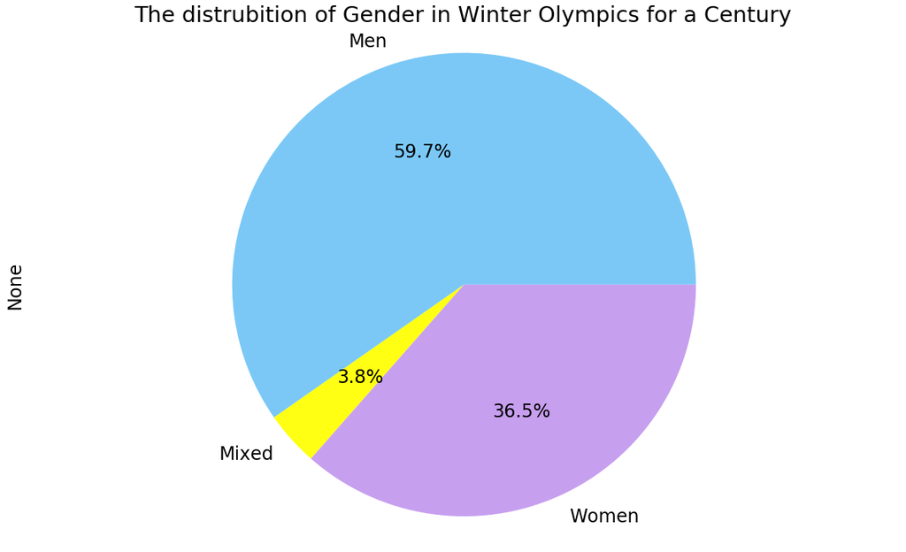

```python
pie_chart('Gender')
#the reason why i created a function for pie chart despite its not being reptitve
#the figure and font size affects other visualizations
```

```python
#sources for pie chart function
#sources: http://www.learningaboutelectronics.com/Articles/How-to-create-a-pie-chart-in-matplotlib-with-Python.php
#stackoverflow and udacity lesson, matplotlib documentation to understand the arguments
#https://stackoverflow.com/questions/3899980/how-to-change-the-font-size-on-a-matplotlib-plot
#https://stackoverflow.com/questions/332289/how-do-i-change-the-size-of-figures-drawn-with-matplotlib
```

#### observation from the visualization: we have noticed that our dataset is dominated by men. One of the main reasons could be that more sports for them were available back then. An interesting fact from our Winter Olympics dataset is that there is a mixed ratio (for pairs and teams).

#### How old are the top five oldest Winter Olympic medalists?

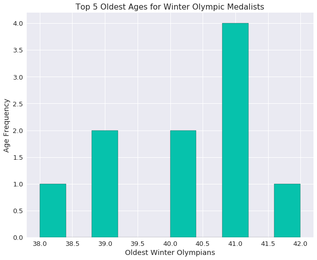

```python
data = w_df['Age of Athlete'].nlargest(n=10)
plt.hist(data, bins=10, edgecolor='black',color = "#06C2AC")
plt.xlabel("Oldest Winter Olympians")
plt.ylabel("Age Frequency")
plt.title('Top 5 Oldest Ages for Winter Olympic Medalists')
fig = plt.gcf()
fig.set_size_inches(10.2, 8.2)
plt.rcParams.update({'font.size': 13})
```

#### Observation: the oldest Olympian is about 42 years old, and 41 is the most common old age among them.

#### How Young are the top five Youngest Winter Olympic medalists?

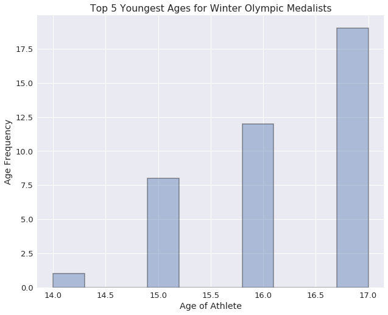

```python
#sources: seaborn documentation + pandas
#edge in displot source: https://datavizpyr.com/add-outine-to-histogram-in-seaborn/
sb.set(rc={'figure.figsize':(10.2, 8.2)})
sb.set(font_scale=1.3)
plt.xlabel("Youngest Winter Olympians")
plt.ylabel("Age Frequency")
plt.title('Top 5 Youngest Ages for Winter Olympic Medalists')
sb.distplot(w_df['Age of Athlete'].nsmallest(n=40),kde=False,bins=10,hist_kws=dict(edgecolor="black", linewidth=1.5))
```

#### Observation: the Youngest Winter Olympian is 14 years old approximately, additionally, 17 is the most common young age among them

#### Which Medal is the most awarded at the Winter Olympics?

```
Text(0.5,1,'Number of Awarded Medals')
```

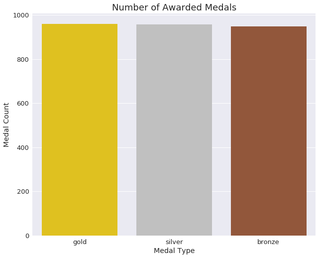

```python
sb.countplot('Medal',data=w_df,palette=['#FFD700',"#C0C0C0",'#A0522D'])
sb.set(rc={'figure.figsize':(12.2, 10.2)})
sb.set(font_scale=1.5)
plt.xlabel("Medal Type")
plt.ylabel("Medal Count")
plt.title('Number of Awarded Medals')
```

#### Observation: Most Awarded medals were Gold and Silver, while bronze is the least awarded medal with a very slightly small difference

#### What is the most participated country in the olympics?

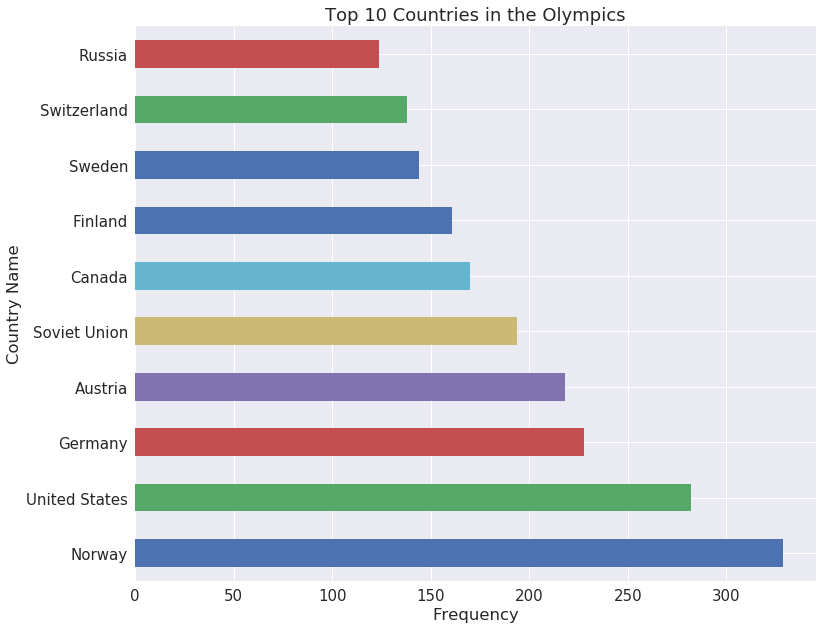

```python
top_countries = w_df['Country'].value_counts()
top_countries[:10].plot(kind='barh')
top_countries[:10].sort_values(ascending=False).plot(kind='barh')
plt.title('Top 10 Countries in the Olympics')
plt.xlabel('Frequency')
plt.ylabel('Country Name');
```

#### observation: Norway is the most participated country

#### Which team\athlete is best in Olympics?

```python
def countplot(column,ylabel,title):
    athlete_order = w_df[column].value_counts(ascending=False)[9::-1].index
    #w_df['Name of Athlete or Team'].value_counts()[9::-1].index
    fig.set_size_inches(10.2, 8.2)
    sb.countplot(data=w_df, y=column, order=athlete_order)
    plt.title(title)
    plt.xlabel('Frequency')
    plt.ylabel(ylabel);
```

```python
#source: #https://www.analyticsvidhya.com/blog/2021/08/understanding-bar-plots-in-python-beginners-guide-to-data-visualization/
```

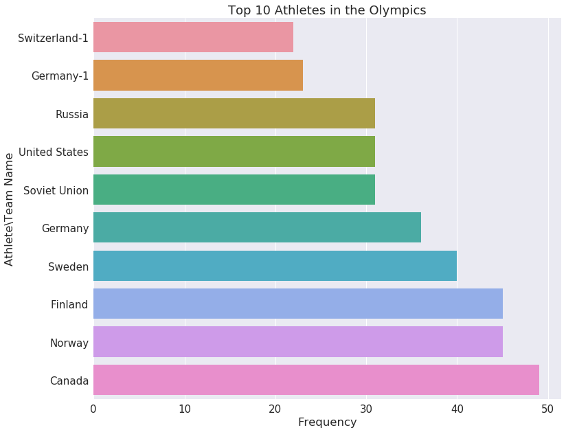

```python
countplot('Name of Athlete or Team','Athlete\Team Name','Top 10 Athletes in the Olympics')
```

#### Observation: Team Canada

#### Which event is best in Olympics?

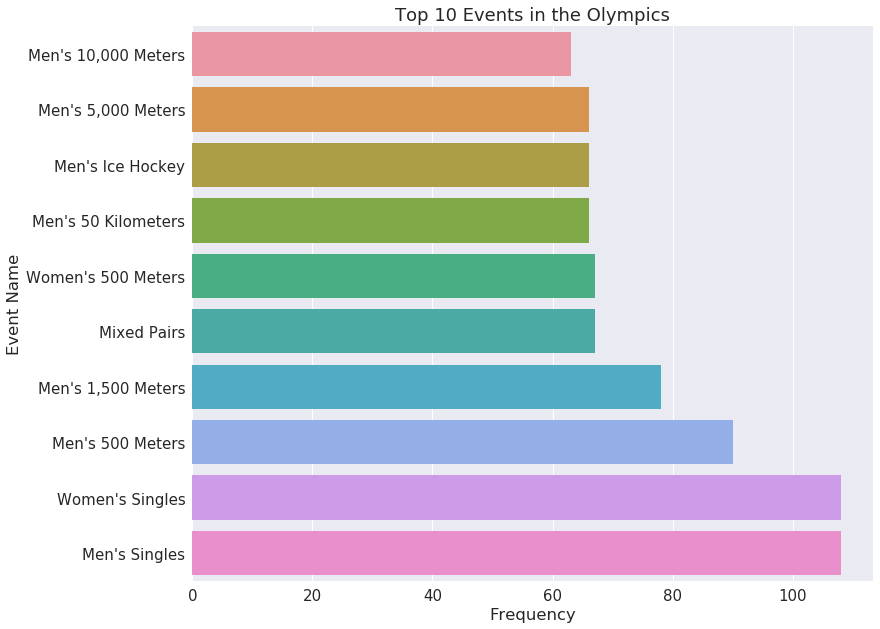

```python
countplot('Event','Event Name','Top 10 Events in the Olympics')
```

#### observation: women and men's single

#### Which sport is best in Olympics?

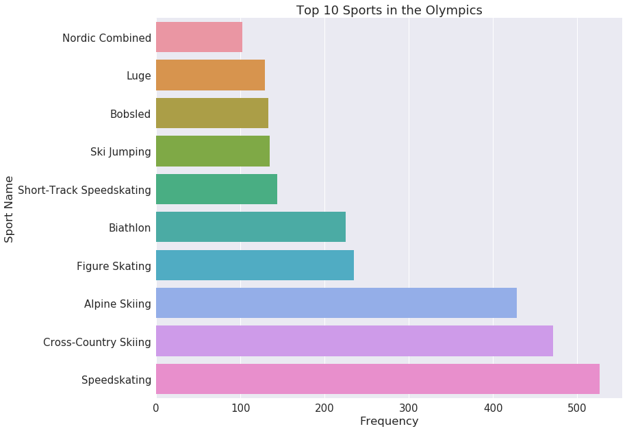

```python
countplot('Sport','Sport Name','Top 10 Sports in the Olympics')
```

### Discuss the distribution(s) of your variable(s) of interest. Were there any unusual points? Did you need to perform any transformations?

> the categorical variables has many values, different sport names, athletes, event and countries, so i had to took the top 10 from each variable and performed observation on each one of them

### Of the features you investigated, were there any unusual distributions? Did you perform any operations on the data to tidy, adjust, or change the form of the data? If so, why did you do this?

> some unsual points happended when discovering the oldest and youngest athletes, because there are both team and athletes names in one column there is Nan values for the ages fot each team/pair, i don't think i can perform any transformation on such an importnat aspect of my dataset

## Bivariate Exploration

> In this section, investigate relationships between pairs of variables in your data. Make sure the variables that you cover here have been introduced in some fashion in the previous section (univariate exploration).

#### When it comes the top 5 countries, which medal dominates each country?

```python
def bi_countplot(column,n,title):
    sb.set(font_scale=1.7)
    sb.set(rc={'figure.figsize':(12.7,8.27)})
    sb.countplot(x=column,data=w_df,hue='Medal',order=w_df[column].value_counts().head(n).index)
    plt.title(title)
```

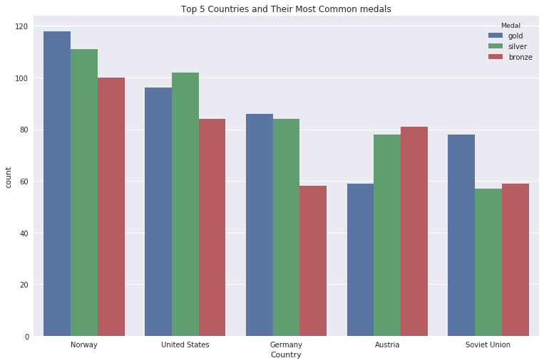

```python
bi_countplot('Country',5,'Top 5 Countries and Their Most Common medals')
```

#### When it comes the top 5 sports, which medal dominates each sport?

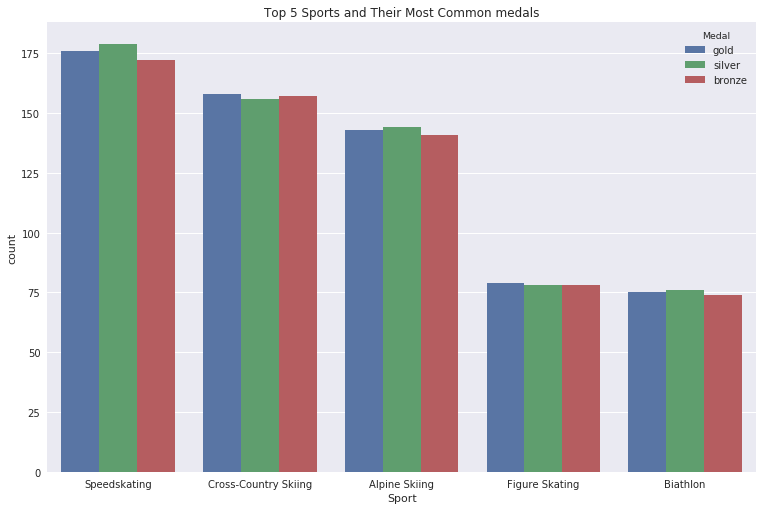

```python
bi_countplot('Sport',5,'Top 5 Sports and Their Most Common medals')
```

#### For Alpine Skiing, silver medals are the most common

#### For Figure Skating, gold medals are the most common

#### For Biathlon, silver medals are the most common

#### When it comes the top 5 teams, which medal dominates each team?

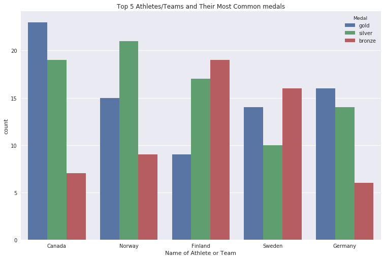

```python
bi_countplot('Name of Athlete or Team',5,'Top 5 Athletes/Teams and Their Most Common medals')
```

#### For Canada, gold medals are the most common

#### For Finland, bronze medals are the most common

#### For Norway, Silver medals are the most common

#### For Sweden, bronze medals are the most common

#### For Germany, gold medals are the most common

#### When it comes to the top 5 Events, which medal dominates each event?

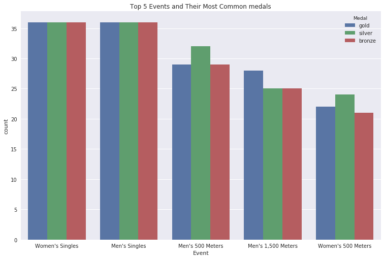

```python
bi_countplot('Event',5,'Top 5 Events and Their Most Common medals')
```

#### When it comes to Gender, which medal is the most common for each one of them?

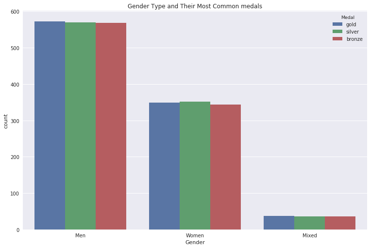

```python
bi_countplot('Gender',3,'Gender Type and Their Most Common medals')
```

#### For Men's Gold medals are the most common

#### For Women's , Silver medals are the most common

#### For Mixed, Gold medals are the most common

### Talk about some of the relationships you observed in this part of the investigation. How did the feature(s) of interest vary with other features in the dataset?

> When it comes to European countries, gold medals are most common, except for Austria (bronze medals are most common there), I think some of our variables, like events (women's singles and men's singles), have equal medal distribution.

## Multivariate Exploration

> Create plots of three or more variables to investigate your data even further. Make sure that your investigations are justified, and follow from your work in the previous sections.

#### what is the relationship between the country, age of athlete and medal?

```python
def pointplot(col,n,title):
    ax = sb.pointplot(data = w_df, x = col, y = 'Age of Athlete', hue = 'Medal', order=w_df[col].value_counts().head(n).index,
                  dodge = 0.3, linestyles = "")
    sb.set(rc={'figure.figsize':(12.7,9.27)})
    plt.title(title)
#source: udacity lesson
```

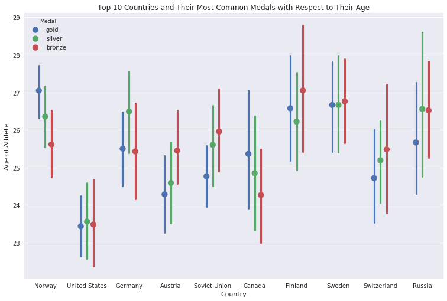

```python
pointplot('Country',10,'Top 10 Countries and Their Most Common Medals with Respect to Their Age')
```

#### observtion: it is really hard to tell the relationship between each variable but i can conclude norway has different age average for each medal(25,26,27), for the united states the average age for each medal are closer (23), it varies from country to another country. but in general the medalists for each country are their in 20s

#### what is the relationship between sport, age of athlete and medal?

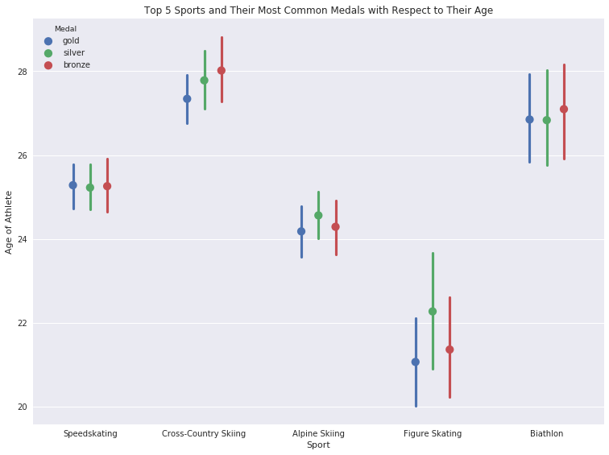

```python
pointplot('Sport',5,'Top 5 Sports and Their Most Common Medals with Respect to Their Age')
```

#### observation: for speed skating, the average age for each medal is very much the same, but when it comes to cross skiing it is slightly different, in general the medalists are most likely in their 20s so age matters at some point

### Talk about some of the relationships you observed in this part of the investigation. Were there features that strengthened each other in terms of looking at your feature(s) of interest?

> i think they have familiar relationship with the numerical variable age since most medalists are in their 20s

### Were there any interesting or surprising interactions between features?

> The average age for speed skating are very close for each medal type

## Conclusions

> Prior to investigation, I assumed that the youngest age for an Olympic medalist was 19. However, during investigation, I discovered that the youngest medalists are in their mid-teenage years (14-17). Additionally, I assumed that medals are awarded equally for each sport and event, but during investigation, I discovered that some sports and events have different frequencies for each medal type. In multivariate analysis, it seems the numerical variable age has an impact on the medalists since the average age for them is in their 20s.

> Remove all Tips mentioned above, before you convert this notebook to PDF/HTML

> At the end of your report, make sure that you export the notebook as an html file from the `File > Download as... > HTML or PDF` menu. Make sure you keep track of where the exported file goes, so you can put it in the same folder as this notebook for project submission. Also, make sure you remove all of the quote-formatted guide notes like this one before you finish your report!